# Home Work Assignment - 04

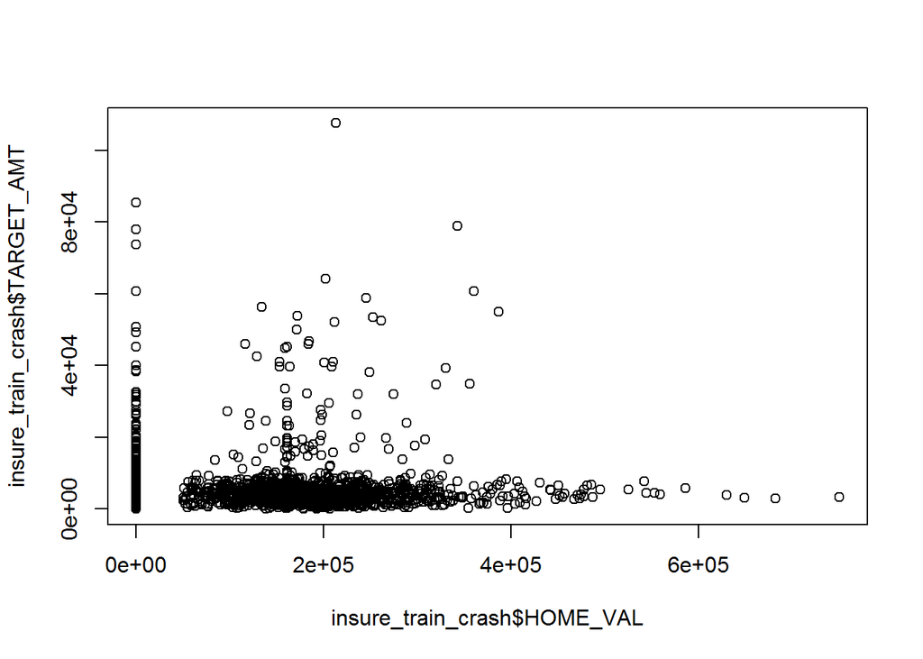

```r
#check_bins("YOJ", c(0:19))

plot(insure_train_crash$HOME_VAL, insure_train_crash$TARGET_AMT)
```

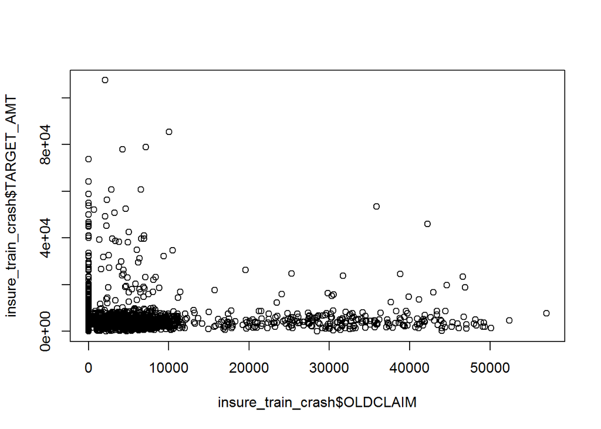

```r
#check_bins("HOME_VAL", c(seq(0, 600000, 10000)))

plot(insure_train_crash$OLDCLAIM, insure_train_crash$TARGET_AMT)
```

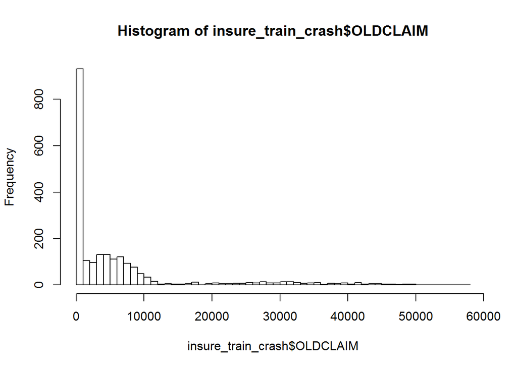

```r
hist(insure_train_crash$OLDCLAIM, breaks=50)
```

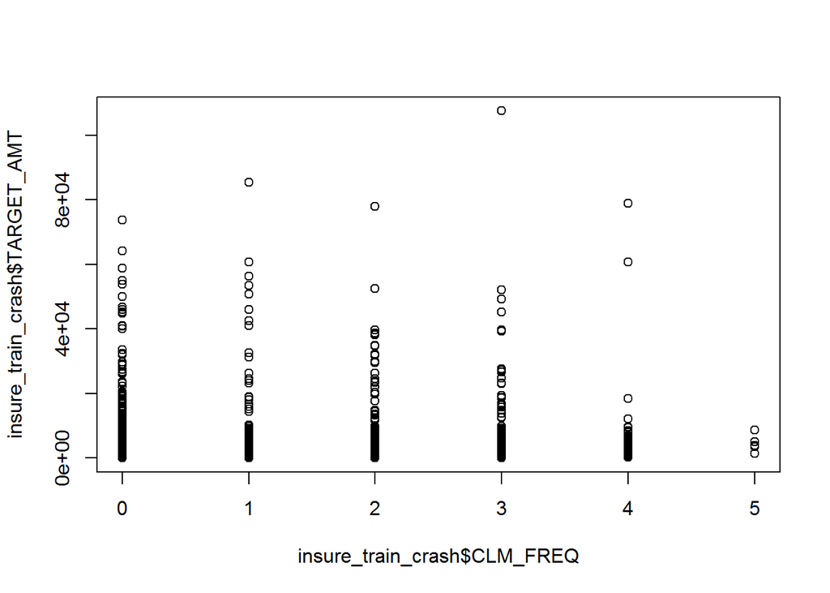

```r
#check_bins("OLDCLAIM", c(seq(0, 50000, 1000)))

#show_hist("CLM_FREQ")
plot(insure_train_crash$CLM_FREQ, insure_train_crash$TARGET_AMT)
```

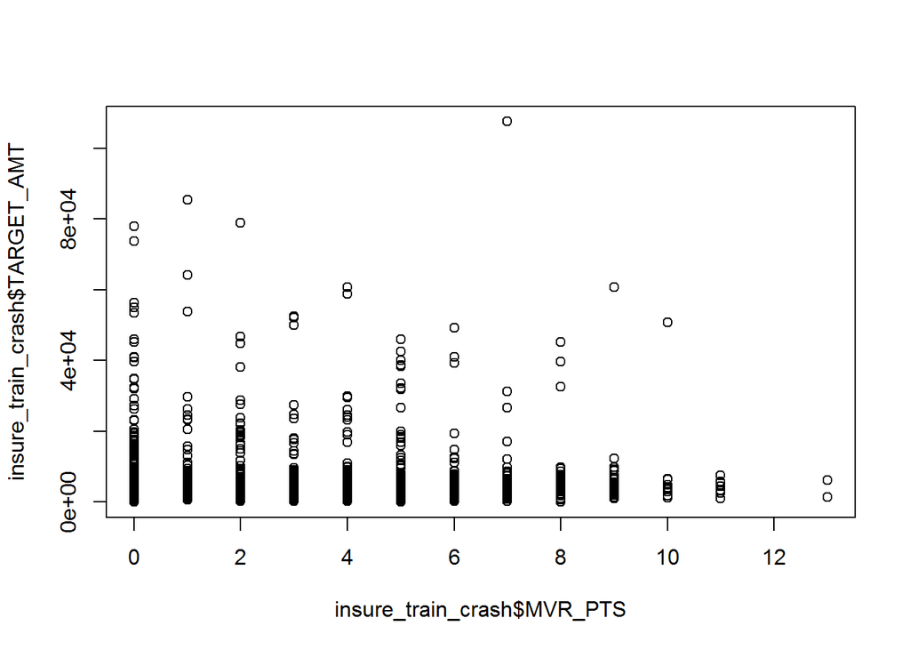

```r
#check_bins("CLM_FREQ", c(0, 1, 2, 3, 4))

#table(insure_train_full$MVR_PTS)
plot(insure_train_crash$MVR_PTS, insure_train_crash$TARGET_AMT)
```

```r
#check_bins("MVR_PTS", c(0:12))

table(insure_train_full$CAR_AGE)
```

```
##
##    1    2    3    4    5    6    7    8    9   10   11   12   13   14   15
## 1934   12   54  135  305  451  524 1047  526  469  460  368  356  311  273
##   16   17   18   19   20   21   22   23   24   25   26   27   28
##  234  213  151  128   90   51   27   18   10    6    2    1    1
```

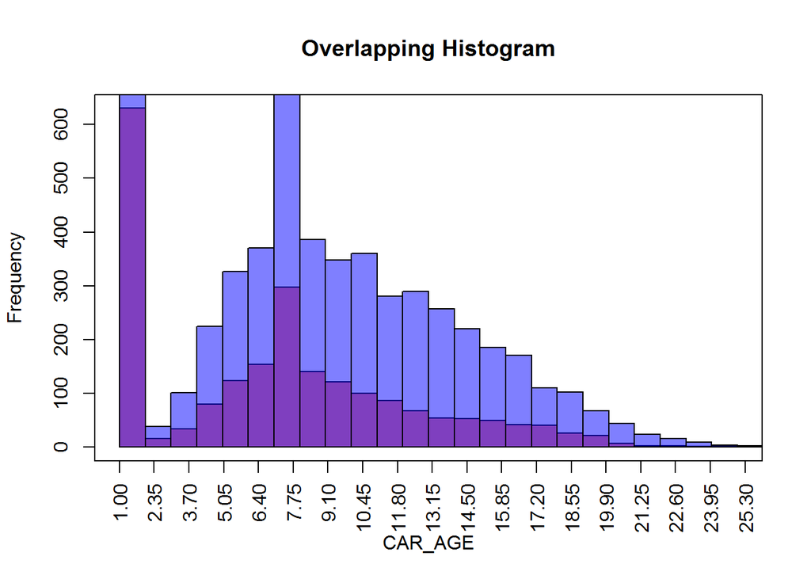

```r
show_hist("CAR_AGE")
```

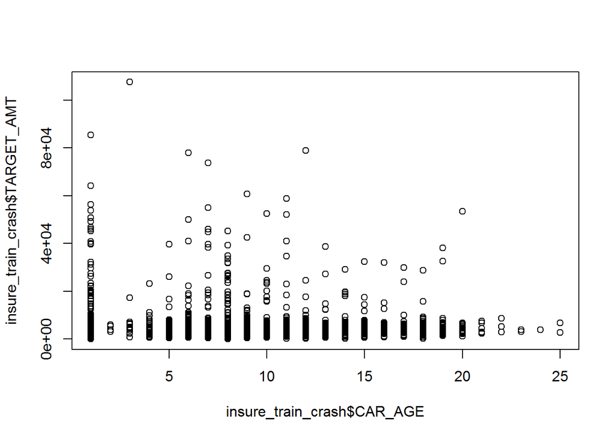

```r
plot(insure_train_crash$CAR_AGE, insure_train_crash$TARGET_AMT)
```

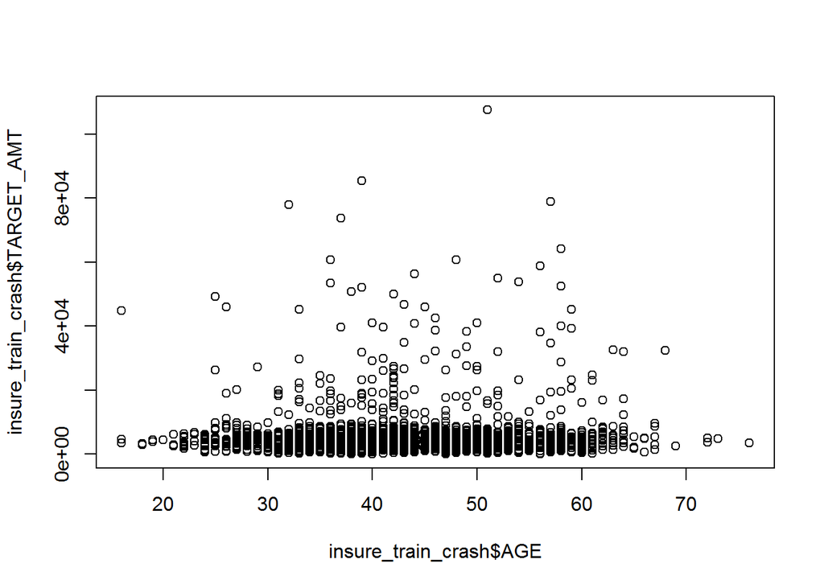

```r
#check_bins("CAR_AGE", c(1:27))

#table(insure_train_full$AGE)
plot(insure_train_crash$AGE, insure_train_crash$TARGET_AMT)
```

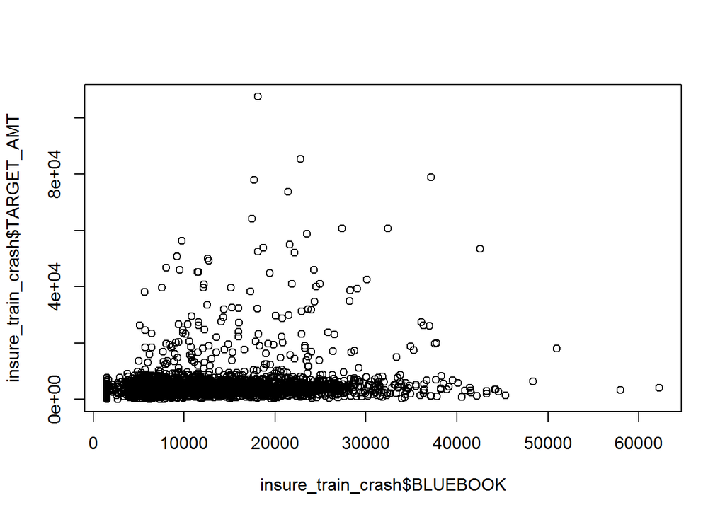

```r
#show_hist("AGE")
#check_bins("AGE", c(16:80))

#table(insure_train_full$BLUEBOOK)
plot(insure_train_crash$BLUEBOOK, insure_train_crash$TARGET_AMT)
```

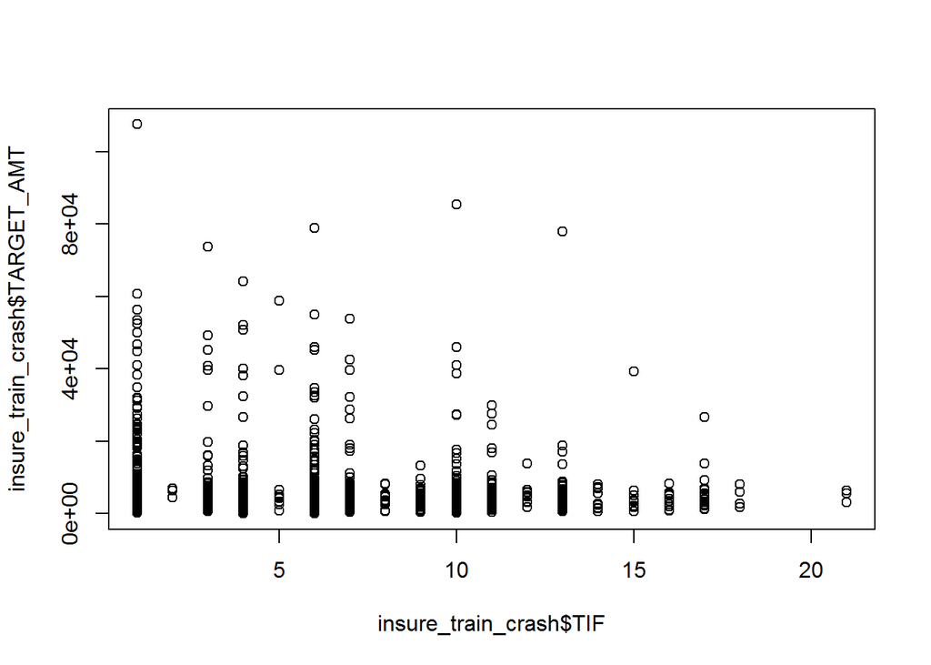

```r
#show_hist("BLUEBOOK")
#check_bins("BLUEBOOK", c(5000, 10000, 20000, 30000, 45000, 57500, 58000))

# table(insure_train_full$TIF)
# show_hist("TIF")
plot(insure_train_crash$TIF, insure_train_crash$TARGET_AMT)
```

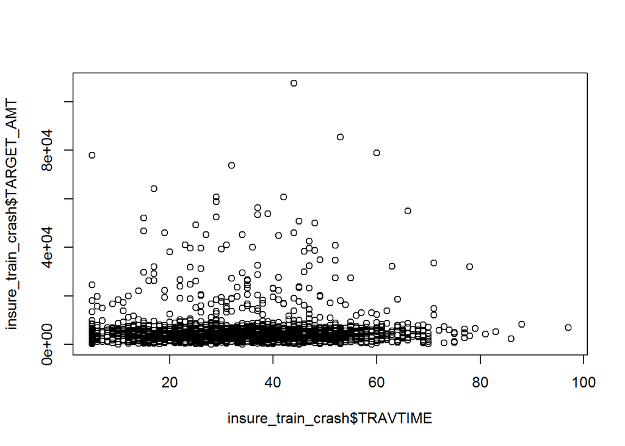

```r
# check_bins("TIF", c(1, 4, 6, 10, 24))

#table(insure_train_full$TRAVTIME)
plot(insure_train_crash$TRAVTIME, insure_train_crash$TARGET_AMT)
```

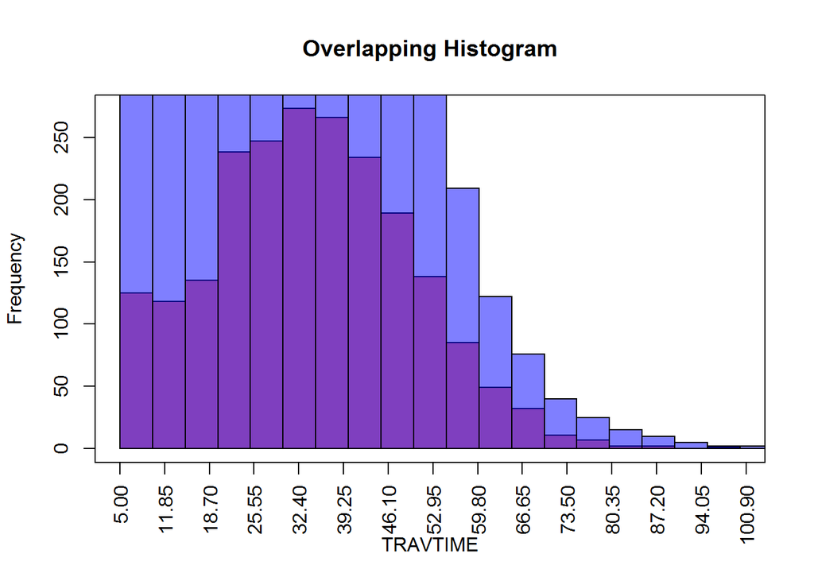

```r
show_hist("TRAVTIME")
```

```r
#check_bins("TRAVTIME", c(21, 59, 120))
```

From the outputs above, we can come to the following conclusions:

- INCOME - From the plot we can see that there is a marked difference in the chart at around 125000. We will use this value to bin this variable.
- YOJ - We can see that from 7 - 17 years, there is a visible change in the TARGET_AMT. We will use this bound to create the binned variable.
- HOME_VAL - We see from the plot 3 distinct segments - Between 0-10000, 60000-400000 and the rest. We will use these values to create 2 bins.
- OLDCLAIM- We can visualize 3 clusters in the data - 0-2000, 2000-10000, > 10000, We will use these values to create 2 bins.
- CLM_FREQ - Values less than 4 seem to have a positive correlation. We will use this value for binning.
- MVR_PTS - We can see from the plot that after 2, the TARGET_AMT starts decreasing. We will use this value for binning.
- CAR_AGE - There are quite a few records with a 1 year car age. We will use this bound to generate a binned variable as well as retain the original varible as is.
- AGE - There is no specific pattern that emerges in AGE. We will retain the variable as is.
- BLUEBOOK - There is no specific pattern that emerges. We will retain the variable as is.
- TIF - Looking at the plot we can conclude that this is not a good variable for binning. We will retain this variable as is.
- TRAVTIME - from the plot, we can see that there is a clear pattern around the value - 20. We will go ahead and create a binned variable for this.

We will carry out the above transformations in the Data Preparation phase.

### 3.1.2 Missing Values

To reiterate, since we started with a “clean” dataset, the missing values have already been handled. Lets take a quick look to confirm.  
Table: Missing Values

|  | missings |
| --- | --- |
| TARGET_AMT | 0 |
| KIDSDRIV | 0 |
| AGE | 0 |
| HOMEKIDS | 0 |
| YOJ | 0 |
| INCOME | 0 |
| HOME_VAL | 0 |
| TRAVTIME | 0 |
| BLUEBOOK | 0 |
| TIF | 0 |
| OLDCLAIM | 0 |
| CLM_FREQ | 0 |
| MVR_PTS | 0 |
| CAR_AGE | 0 |
| PARENT1_Yes | 0 |
| MSTATUS_Yes | 0 |
| SEX_M | 0 |
| EDUCATION_Bachelors | 0 |
| EDUCATION_High.School | 0 |
| EDUCATION_Masters | 0 |
| EDUCATION_PhD | 0 |
| JOB_Blue.Collar | 0 |
| JOB_Clerical | 0 |
| JOB_Doctor | 0 |
| JOB_Home.Maker | 0 |
| JOB_Lawyer | 0 |
| JOB_Manager | 0 |
| JOB_Professional | 0 |
| JOB_Student | 0 |
| JOB_Unknown | 0 |
| CAR_USE_Commercial | 0 |
| CAR_TYPE_Minivan | 0 |
| CAR_TYPE_Panel.Truck | 0 |
| CAR_TYPE_Pickup | 0 |
| CAR_TYPE_Sports.Car | 0 |
| CAR_TYPE_SUV | 0 |
| CAR_TYPE_Van | 0 |
| RED_CAR_yes | 0 |
| REVOKED_Yes | 0 |
| URBANICITY_Rural | 0 |

### 3.1.3 Outliers identification

In this sub-section, we will look at the boxplots and determine the outliers in variables and decide on whether to act on the outliers.  
We will do the outliers only on the numeric variables: AGE, BLUEBOOK and TIF. The other variables will be binned and would not beed outlier handling.  
Below are the plots:

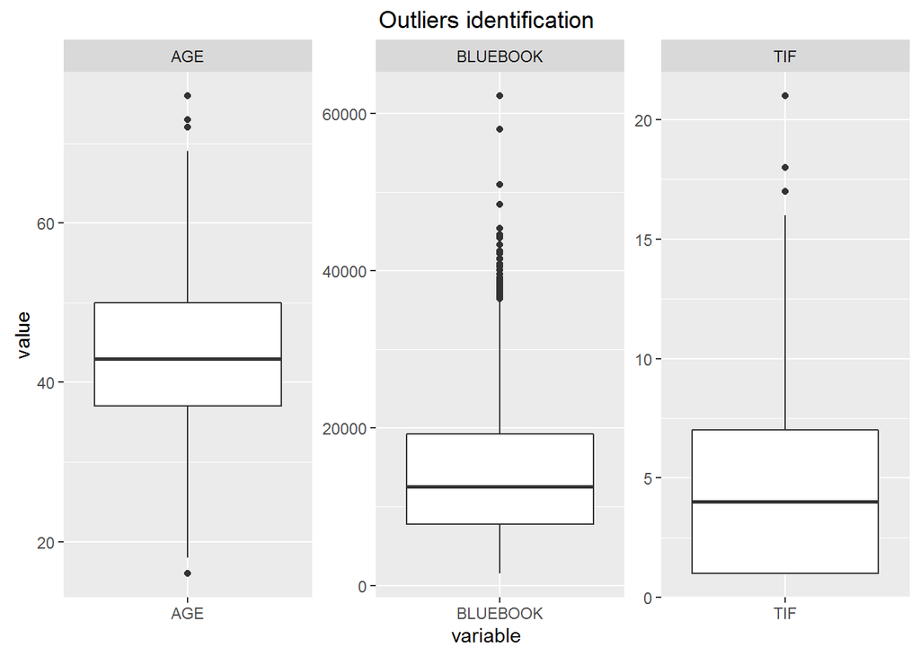

From the “Outliers identification” plot above, we see that we have few outliers that we need to treat.  
We see thatall the 3 variables need to be treated when we do the data preparation for modeling the TARGET_AMT.

## 3.2 Data Preparation

Now that we have completed the data exploration / analysis, we will be transforming the data for use in analysis and modeling.  
We will be following the below steps as guidelines:  
- Outliers treatment  
- Missing values treatment  
- Adding New Variables

### 3.2.1 Outliers treatment

In this sub-section, we will check different transformations for each of the variables - AGE, BLUEBOOK, TIF - and create the appropriate outlier-handled / transformed variables.

**Transformations for AGE**

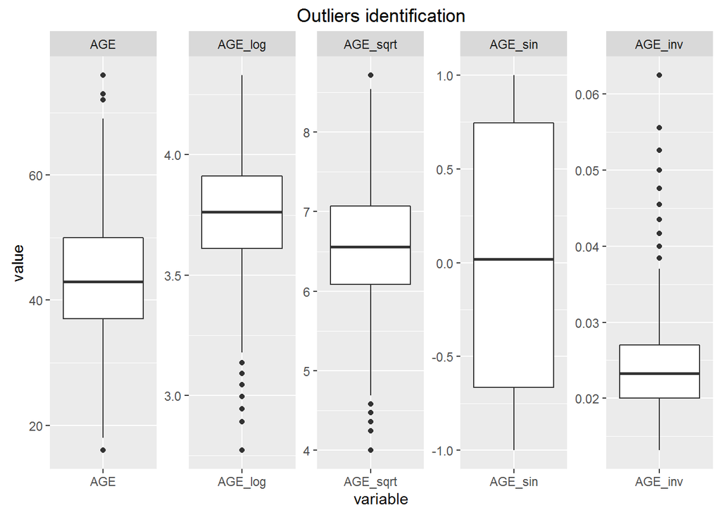

From the above charts we can see that a sin transformation works well for AGE. We will create this variable.

**Transformations for TIF**

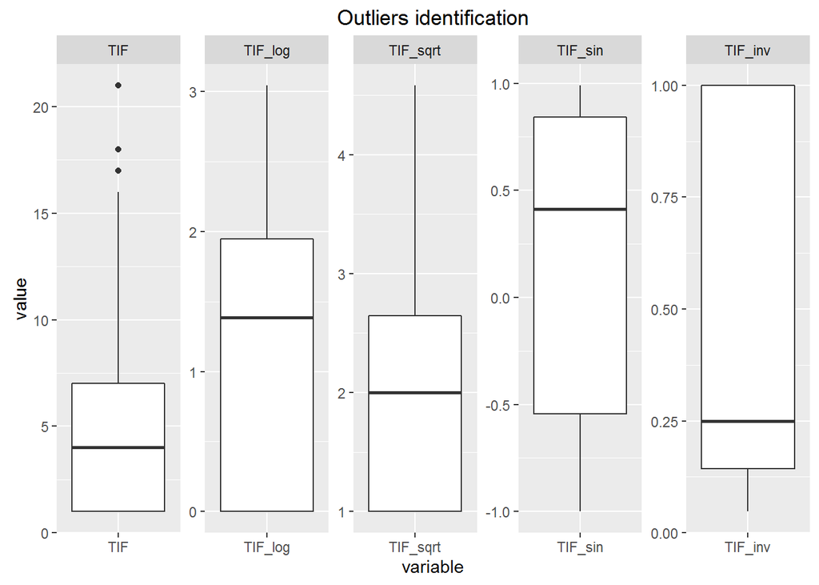

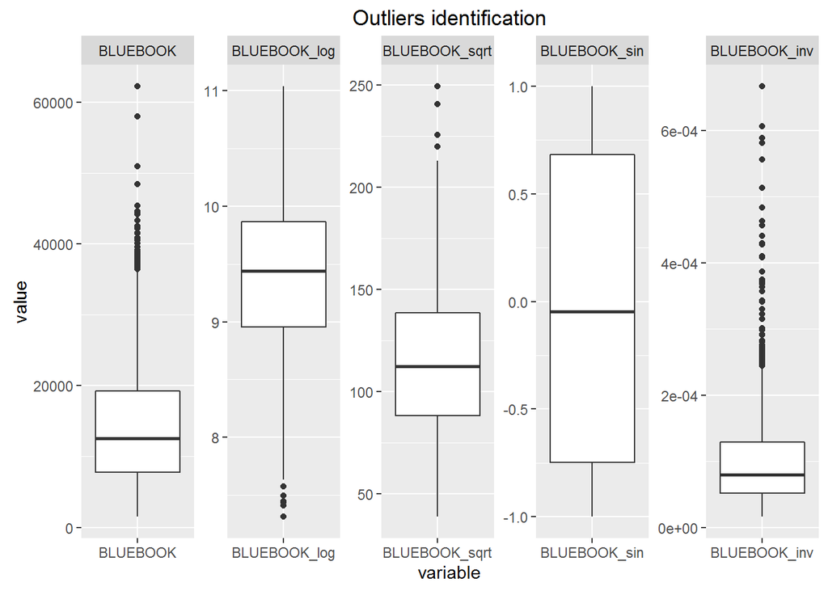

From the above charts we can see that a sin transformation works well for BLUEBOOK. We will create these variables.